# 计量经济学Eviews实验指导书

Lab 4 多元线性回归及矩阵运算

胡华平

2018/3/27

# 1 实验目的及要求

- **目的**：掌握多元线性回归模型的估计、检验。
- **要求**：在老师指导下完成多元线性回归模型的建立、估计、统计检验，得到正确的分析结果；能运用矩阵方法实现前述操作。

# 2 实验原理

- 当多元线性回归模型在满足线性模型古典假设的前提下，最小二乘估计结果具有无偏性、有效性等性质，在此基础上进一步对估计所得的模型进行经济意义检验及统计检验。

## 2.1 k变量线性回归模型的矩阵表达

k变量总体回归模型(PRF)的代数表达式如下：
$$\begin{equation}
Y_i=\beta_1+\beta_2X_{2i}+\beta_2X_{2i}+\cdots++\beta_kX_{ki}+u_i
\tag{2.1}
\end{equation}$$

如果样本数为n，则k变量总体回归模型矩阵表达为：
$$\begin{align}
\begin{bmatrix}
Y_1 \\ Y_2 \\ \cdots \\ Y_n \\
\end{bmatrix} &=
\begin{bmatrix}
1 & X_{21} & X_{31} & \cdots & X_{k1} \\
1 & X_{22} & X_{32} & \cdots & X_{k2} \\
\cdots & \cdots & \cdots & \cdots & \cdots \\
1 & X_{2n} & X_{3n} & \cdots & X_{kn}
\end{bmatrix}
\begin{bmatrix}
\beta_1 \\ \beta_2 \\ \vdots \\ \beta_k \\
\end{bmatrix}+
\begin{bmatrix}
u_1 \\ u_2 \\ \vdots \\ u_n \\
\end{bmatrix}
\tag{2.2} \\
\mathbf{y} &= \mathbf{X\beta+u} \tag{2.3} \\
(n \times 1) &= (n \times n) (k \times 1)+(n \times 1)
\end{align}$$

## 2.2 经典线性回归模型假定的矩阵表述

## 2.3 OLS估计及BLUE性质证明的矩阵表达

## 2.4 对回归系数进行显著性检验

## 2.5 对回归模型进行总体显著性检验

### 2.5.1 方差分析表(ANOVA)的矩阵表述

### 2.5.2 总体模型显著性的F检验

## 2.6 用多元回归做预测:矩阵表述

# 3 实验内容

## 3.1 实验方案设计

在Eviews中运用**矩阵方法**，计算如下步骤:

- 计算直线回归方程的回归系数向量($\mathbf{\hat{\beta}}$)，并写出样本回归模型（$SRM$）。
- 计算回归误差方差($\hat{\sigma}^2$)和回归误差标准差($\hat{\sigma}$)。
- 计算回归系数的样本方差协方差矩阵($\widehat{var}\_\widehat{cov}$)。
- 得出回归系数的样本标准差向量($S_{\hat{\beta}}$)。
- 进行平方和分解，计算$TSS$、$ESS$和$RSS$。
- 计算判定系数$R^2$，调整判定系数($\hat{R}^2$)。
- 计算样本t统计量($\mathbf{t^{\ast}_{\beta}}$)，并进行t假设检验。
- 对回归方程的进行样本外均值预测$E(Y|X=X_0)$
- 对回归方程的进行样本外个值预测$(Y_0|X=X_0)$

## 3.2 实验背景——玫瑰的需求

**玫瑰的需求**：表3.1给出美国底特律市区对玫瑰的季度需求数据。

表3.1: 玫瑰的需求(n=16)

| YEAR | Q | X2 | X3 | X4 | X5 |
| --- | --- | --- | --- | --- | --- |
| 1971.3 | 11484 | 2.26 | 3.49 | 158.11 | 1 |
| 1971.4 | 9348 | 2.54 | 2.85 | 173.36 | 2 |
| 1972.1 | 8429 | 3.07 | 4.06 | 165.26 | 3 |
| 1972.2 | 10079 | 2.91 | 3.64 | 172.92 | 4 |
| 1972.3 | 9240 | 2.73 | 3.21 | 178.46 | 5 |
| 1972.4 | 8862 | 2.77 | 3.66 | 198.62 | 6 |
| 1973.1 | 6216 | 3.59 | 3.76 | 186.28 | 7 |
| 1973.2 | 8253 | 3.23 | 3.49 | 188.98 | 8 |
| 1973.3 | 8038 | 2.60 | 3.13 | 180.49 | 9 |
| 1973.4 | 7476 | 2.89 | 3.20 | 183.33 | 10 |
| 1974.1 | 5911 | 3.77 | 3.65 | 181.87 | 11 |
| 1974.2 | 7950 | 3.64 | 3.60 | 185.00 | 12 |
| 1974.3 | 6134 | 2.82 | 2.94 | 184.00 | 13 |
| 1974.4 | 5868 | 2.96 | 3.12 | 188.20 | 14 |
| 1975.1 | 3160 | 4.24 | 3.58 | 175.67 | 15 |
| 1975.2 | 5872 | 3.69 | 3.53 | 188.00 | 16 |

变量说明见表3.2：

表3.2: 变量定义及说明

| variable | label |
| --- | --- |
| YEAR | 年份.季度 |
| Q | 玫瑰销售量(打) |
| X2 | 玫瑰批发价格($/打) |
| X3 | 石竹的平均批发价格($/打) |
| X4 | 家庭可支配收入($/周) |
| X5 | 时间趋势 |

请考虑如下两个需求函数：

$$\begin{equation}
Y_t=\hat{\alpha}_1+\hat{\alpha}_2X_{2t}+\hat{\alpha}_3X_{3t}+
\hat{\alpha}_4X_{4t}+\hat{\alpha}_5X_{5t}+e_{1t}
\tag{3.1}
\end{equation}$$
$$\begin{equation}
ln(Y_t)=\hat{\beta}_1+\hat{\beta}_2ln(X_{2t})+\hat{\beta}_3ln(X_{3t})+\hat{\beta}_4ln(X_{4t})+\hat{\beta}_5X_{5t}+e_{2t}
\tag{3.2}
\end{equation}$$

$$\begin{equation*}
ln(Y_t)=\hat{\beta}_1+\hat{\beta}_2ln(X_{2t})+\hat{\beta}_3ln(X_{3t})\hat{\beta}_4ln(X_{4t})+\hat{\beta}_5X_{5t}+e_{2t}
\tag{3.3}
\end{equation*}$$

调用chunk模型(3.4)
$$\begin{equation}
ln(Y_t)=\hat{\beta}_1+\hat{\beta}_2ln(X_{2t})+\hat{\beta}_3ln(X_{3t})\hat{\beta}_4ln(X_{4t})+\hat{\beta}_5X_{5t}+e_{2t}
\tag{3.4}
\end{equation}$$

chunk调用结果如下:
$$\begin{equation}
ln(Y_t)=\hat{\beta}_1+\hat{\beta}_2ln(X_{2t})+\hat{\beta}_3ln(X_{3t})\hat{\beta}_4ln(X_{4t})+\hat{\beta}_5X_{5t}+e_{2t}
\tag{3.4}
\end{equation}$$

【本次实验题目完毕啦！！】

# 4 主要实验步骤——以对数模型$M_2$为例(3.2)

## 4.1 Eviews变量命名设计

表4.1: 计算对象、表达式及Eviews命名

| name_chn | cat_eng | math | name_eviews |
| --- | --- | --- | --- |
| 序列Y | series | $Y$ | y |
| 组X | group | $X$ | xg |
| 矩阵y | matrix | $\mathbf{y}$ | y |
| 矩阵x | matrix | $\mathbf{X}$ | x |
| 矩阵xtx | matrix | $\mathbf{(X'X)}$ | xtx |
| 矩阵xtxi | matrix | $\mathbf{{(X'X)}^{-1}}$ | xtxi |
| 矩阵xty | matrix | $\mathbf{X'y}$ | xty |
| 矩阵beta | matrix | $\mathbf{\hat{\beta}}$ | beta_hat |
| 回归误差方差 | scalar | $\hat{\sigma}^2$ | sigma2_hat |
| 回归误差标准差 | scalar | $\hat{\sigma}$ | sigma_hat |
| beta样本方差协方差矩阵 | matrix | $\widehat{var}\_\widehat{cov}(\mathbf{\hat{\beta}})$ | s2_varcov_beta_hat |
| beta样本方差矩阵 | matrix | $\mathbf{S_{\hat{\beta}}^2}$ | s2_beta_hat |
| beta样本标准差矩阵 | matrix | $\mathbf{S_{\hat{\beta}}}$ | s_beta_hat |
| 均值修正值 | scalar | $n\bar{Y}^2$ | mean_adj |
| 总平方和 | scalar | $TSS$ | tss |
| 残差平方和 | scalar | $RSS$ | rss |
| 回归平方和 | scalar | $ESS$ | ess |
| 判定系数 | scalar | $R^2$ | r2 |
| 调整判定系数 | scalar | $\bar{R}^2$ | r2_adj |
| 矩阵t统计量 | matrix | $\mathbf{t^{\ast}_{\beta}}$ | t_str_beta_hat |
| 理论t值 | scalar | $t_{1-\alpha/2}(n-k)$ | t_value |
| F统计量 | scalar | $F^{\ast}$ | f_str |
| 理论F值 | scalar | $F_{1-\alpha}(k-1,n-k)$ | f_value |
| 样本外X0 | matrix | $X_0$ | x0 |
| 样本外回归值Y0_hat | matrix | $\hat{Y}_0$ | Y0_hat |
| 均值预测 | scalar | $E(Y\|X=X_0)$ | forecast_exp |
| Y0_hat的样本标准差 | scalar | $S_{\hat{Y}_0}$ | s_y0h |
| 均值区间预测的左界 | scalar | $E(Y\|X=X_0)_L$ | y_exp_lft |
| 均值区间预测的右界 | scalar | $E(Y\|X=X_0)_R$ | y_exp_rht |
| 个值预测 | scalar | $(Y_0\|X=X_0)$ | forecast_ind |
| Y0_hat-Y0的样本标准差 | scalar | $S_{(\hat{Y}_0-Y_0)}$ | s_y0h_mns_y0 |
| 个值区间预测的左界 | scalar | $(Y_0\|X=X_0)_L$ | y_ind_lft |
| 个值区间预测的右界 | scalar | $(Y_0\|X=X_0)_R$ | y_ind_rht |

## 4.2 导入数据并进行预处理

- 目标：
- 思路：
- 新建Eviews工作文件（workfile）
  - 提示：Excel数据，每个同学的Y数据都不同，找到自己学号对应下的Y
  - Eviews菜单操作：
    1. 依次操作：file——》new——》workfile
    2. 进行workfile create引导设置：
       - workfile structure type: `unstructured/undatede`
       - data range：16
       - workfile names(optional):
         - WF: `rose demand`
         - Page: `model2` （**强烈建议命名model2！**）
  - 注意：本次实验涉及到两个模型的比较——经典模型(3.1) 和对数模型(3.2)。为避免两个模型Eviews变量命名的冲突，请务必注意分别在两个Page里分别完成两个模型的数据分析！
- 导入数据
  - 提示：Excel数据，每个同学的Y数据都不同，找到自己学号对应下的Y数据（X数据所有同学都一样）
  - （方法1）菜单操作（Excel和Eviews）：
    1. Excel找到数据。Excel表格中仅保留自己需要的数据（YEAR, Q, X2, X3, X4, X5）
    2. Excel处理变量。加入一个新变量（建议命名为`cst`），并给该变量的数据全部设置为1。
    3. Eviews导入数据。File——》Import——》Import From File：`d:/econometrics/data/lab4-rose-demand-lab.csv`
  - （方法2）命令操作（Eviews）：尤其注意常数序列`cst`的命令生成过程。
    1. Eviews命令窗口输入并运行代码：`series cst=1`
    2. Eviews命令窗口输入并运行代码：`series ln_x2=log(x2)`
    3. Eviews命令窗口输入并运行代码：`series ln_x3=log(x3)`
    4. Eviews命令窗口输入并运行代码：`series ln_x4=log(x4)`
  - 说明：构造Eviews对象`cst`，是为了进一步构造矩阵。在有截距模型中，矩阵$\mathbf{X}$的第一列元素应全部设置为1。

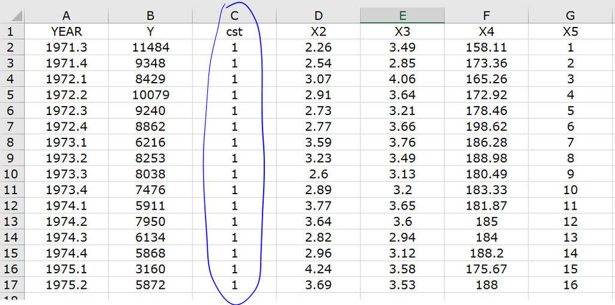

  图4.1: Excel数据与变量预处理

- 构造组（group）对象xg
  - 提示：把因变量`X`序列（series）和常数`cst`序列（series）对象一起转换成矩阵（matrix）对象
  - 得到序列组$X$
    - 命名：建议将样本数据序列组的Eviews对象命名为xg
    - 菜单：依次选择( `cst ln_x2 ln_x3 ln_x4 x5`)—>open as group —>name（建议命名为xg）
- 得到矩阵$\mathbf{X}$
  - 命名：建议将样本数据矩阵$\mathbf{X}$的Eviews对象命名为x
  - 命令：matrix x=xg

## 4.3 计算直线回归方程的回归系数向量($\mathbf{\hat{\beta}}$)，并写出样本回归模型（$SRM_2$）。

- 目标：根据理论的矩阵公式，计算得到直线回归方程的回归系数向量($\mathbf{\hat{\beta}}$)
- 思路：
- 构造矩阵$\mathbf{y}$
  - 提示：把因变量`Y`序列(series)对象转化成矩阵对象
  - 命名：建议将样本数据矩阵$\mathbf{y}$的Eviews对象命名为y +命令：matrix y=q
- 构造矩阵$\mathbf{X}$
  - 提示：把因变量`X`序列(series)对象转化成矩阵对象
  - 得到序列组$X$
    1. 命名：建议将样本数据序列组$X$的Eviews对象命名为xg
    2. 菜单：依次选择( `cst ln_x2 ln_x3 ln_x4 x5`)—>open as group —>name（建议命名为xg）
  - 得到矩阵$\mathbf{X}$：
    1. 命名：建议将样本数据矩阵$\mathbf{X}$的Eviews对象命名为x
    2. 命令：matrix x=xg
- 利用矩阵公式计算回归系数($\mathbf{\hat{\beta}}$)
  - 得到重要矩阵$\mathbf{(X'X)}$
    1. 命名：建议将重要矩阵$\mathbf{(X'X)}$的Eviews对象命名为xtx
    2. 命令：matrix xtx=@transpose(x)*x
  - 得到重要矩阵$\mathbf{{(X'X)}^{-1}}$
    1. 命名：建议将重要矩阵$\mathbf{{(X'X)}^{-1}}$的Eviews对象命名为xtxi
    2. 命令： matrix xtxi=@inverse(xtx)
  - 得到重要矩阵$\mathbf{X'y}$（建议命名为xty）
    1. 命名：建议将重要矩阵$\mathbf{X'y}$的Eviews对象命名为xty
    2. 命令： matrix xty=@transpose(x)*y
  - 得到回归系数矩阵$\mathbf{\hat{\beta}}$
    1. 提示：回归系数矩阵$\mathbf{\hat{\beta}}$的理论计算公式为
       $$\mathbf{\hat{\beta}}=\mathbf{{(X'X)}^{-1}X'y}$$
    2. 命名：建议将回归系数矩阵$\mathbf{\hat{\beta}}$的Eviews对象命名为beta_hat
    3. 命令：matrix beta_hat=xtxi*xty

## 4.4 计算回归误差方差($\hat{\sigma}^2$)和回归误差标准差($\hat{\sigma}$)

- 目标：根据理论的矩阵公式，回归误差方差($\hat{\sigma}^2$)和回归误差标准差($\hat{\sigma}$)
- 思路：
- 提示：回归误差方差($\hat{\sigma}^2$)和回归误差标准差($\hat{\sigma}$)的理论计算公式分别为：

$$\hat{\sigma}^2=\frac{\sum{e_i^2}}{n-k}=\frac{\mathbf{y'y-\hat{\beta}'X'y}}{n-k}$$
$$\hat{\sigma}=\sqrt{\frac{\sum{e_i^2}}{n-k}}=\sqrt{\frac{\mathbf{yy'-\hat{\beta}'X'y}}{n-k}}$$

- 命名：建议将回归误差方差的Eviews对象命名为sigma2_hat，将回归误差标准差的Eviews对象命名为sigma_hat。
- 命令：
  - 回归误差方差$\hat{\sigma}^2$: scalar sigma2_hat=1/(16-5)*(@transpose(y)*y-@transpose(beta_hat)*xty)
  - 回归误差标准差 $\hat{\sigma}$: scalarsigma_hat=@sqr(sigma2_hat)
- 注意：与eviews报告比对是否正确（注：要开根号才能比较！）

## 4.5 计算回归系数的样本方差协方差矩阵($\widehat{var}\_\widehat{cov}(\mathbf{\hat{\beta}})$)

- 目标：根据理论的矩阵公式，计算回归系数的样本方差协方差矩阵($\widehat{var}\_\widehat{cov}(\mathbf{\hat{\beta}})$)
- 思路：
- 提示：回归系数的样本方差协方差矩阵阵($\widehat{var}\_\widehat{cov}(\mathbf{\hat{\beta}})$)的理论计算公式为：

$$\widehat{var}\_\widehat{cov}(\mathbf{\hat{\beta}})=\hat{\sigma}^2\mathbf{(X'X)^{-1}}$$

- 命名：建议将样本方差协方差矩阵的Eviews对象命名为s2_varcov_beta_hat
- 命令：matrix s2_varcov_beta_hat=sigma2_hat*xtxi
- 注意：与eviews报告比对是否正确（注：要开根号才能比较！）

## 4.7 进行平方和分解，计算$TSS$、$ESS$和$RSS$

- 目标：根据理论的矩阵公式，进行平方和分解，计算$TSS$、$ESS$和$RSS$
- 思路：
- 计算均值修正值$n\bar{Y}^2$
  - 提示：均值修正值的理论公式为

  $$n\bar{Y}^2$$
  - 命名：建议将均值修正值的Eviews对象命名为mean_adj
  - 命令：scalar mean_adj=16*(@mean(y))^2
- 计算总平方和$TSS$
  - 提示：总平方和$TSS$的理论计算公式为

  $$TSS=\mathbf{y'y}-n\bar{Y}^2$$
  - 命名：建议将总平方和的Eviews对象命名为tss
  - 命令：scalar tss=@transpose(y)*y-mean_adj
- 计算残差平方和$RSS$
  - 提示：残差平方和$RSS$的理论计算公式为：

  $$RSS=\mathbf{e'e}=\mathbf{y'y-\hat{\beta}'X'y}$$
  - 命名：建议将残差平方和的Eviews对象命名为rss
  - 命令：scalar rss=@transpose(y)*y-@transpose(beta_hat)*xty
  - 注意：与eviews报告比对是否正确
- 计算回归平方和$ESS$
  - 提示：回归平方和$ESS$的理论计算公式为：

  $$ESS=\mathbf{e'e}=\mathbf{\hat{\beta}'X'y}-n\bar{Y}^2$$
  - 命名：建议将回归平方和的Eviews对象命名为ess
  - 命令：scalar ess=@transpose(beta_hat)*xty-mean_adj

## 4.8 计算判定系数$R^2$和调整判定系数($\bar{R}^2$)

- 目标：根据理论的矩阵公式，计算判定系数$R^2$和调整判定系数($\bar{R}^2$)
- 思路：
- 计算判定系数$R^2$
  - 提示：理论计算公式为：

  $$R^2=\frac{ESS}{TSS}=\frac{\mathbf{\hat{\beta}'X'y}-n\bar{Y}^2}{\mathbf{y'y}-n\bar{Y}^2}$$
  - 命名：建议将判定系数的Eviews对象命名为r2
  - 命令：scalar r2=ess/tss
  - 注意：与eviews报告比对是否正确
- 计算调整判定系数($\bar{R}^2$)
  - 提示：判定系数$\bar{R}^2$的理论计算公式为

  $$\bar{R}^2=1-\frac{RSS/{f_{RSS}}}{TSS/{f_{TSS}}}=1-\frac{\mathbf{y'y-\hat{\beta}X'y}/{n-k}}{{(\mathbf{y'y}-n\bar{Y}^2)}/{n-1}}$$
  - 命名：建议将调整判定系数的Eviews对象命名为r2_adj
  - 命令：scalar r2_adj=1-(rss/11)/(tss/15)
  - 注意：与eviews报告比对是否正确

## 4.9 计算得到样本t统计量($\mathbf{t^{\ast}_{\beta}}$)

- 目标：根据理论的矩阵公式，计算样本t统计量($\mathbf{t^{\ast}_{\beta}}$)，并进行t假设检验
- 思路：
- 提示：样本t统计量$\mathbf{t^{\ast}_{\beta}}$的理论计算公式为

$$\mathbf{t^{\ast}_{\beta}=\frac{\hat{\beta}}{S_{\hat{\beta}}}}$$

- 命名：建议将样本t统计量的Eviews对象命名为t_str_beta_hat
- 命令：matrix t_str_beta_hat=@ediv(beta_hat,s_beta_hat)
- 注意：与Eviews报告比对是否正确。Eviews命令`@ediv()`的作用是将矩阵对应元素进行相除。

## 4.10 计算给定$\alpha=0.05$水平下的查表的理论t值($t_{1-\alpha/2}(n-k)$)，并进行t假设检验

- 目标：根据理论的矩阵公式，计算查表的理论t值($t_{1-\alpha/2}(n-k)$)，并进行t假设检验
- 思路：
- 提示：查表的理论t值($t_{1-\alpha/2}(n-k)$)的理论计算公式为：

$$t_{1-\alpha/2}(n-k)=t_{0.975}(11)$$

- 命名：建议将查表理论t值的Eviews对象命名为t_value
- 命令：scalar t_value=@qtdist(0.975,11)

## 4.11 对回归方程的整体显著性进行F假设检验

- 目标：根据理论的矩阵公式，计算样本F统计量，并进行模型整体显著性检验
- 思路：
- 提示：样本F统计量$F^{\ast}$的理论计算公式为：

$$F^{\ast}=\frac{ESS/{f_{ESS}}}{RSS/{f_{RSS}}}=\frac{MSS_{ESS}}{MSS_{RSS}}=\frac{(\mathbf{\hat{\beta}X'y}-n\bar{Y}^2)/{k-1}}{{(\mathbf{y'y-\hat{\beta}'X'y})}/{n-k}}$$

- 命名：建议将样本F统计量的Eviews对象命名为f_str
- 命令：scalar f_str=(ess/4)/(rss/11)
- 注意：与eviews报告比对是否正确。

## 4.12 计算给定$\alpha=0.05$水平下的查表的理论F值($F_{1-\alpha}(k-1,n-k)$)，并进行F假设检验

- 目标：根据理论的矩阵公式，计算查表的理论F值($F_{1-\alpha}(k-1,n-k)$)，并进行F假设检验
- 思路：
- 提示：查表的理论F值($F_{1-\alpha}(k-1,n-k)$)的理论计算公式为：

$$F_{1-\alpha}(k-1,n-k)=F_{0.95}(4,11)$$

## 4.13 对回归方程的进行样本外均值预测$E(Y|X=X_0)$

- 目标：根据理论的矩阵公式，计算样本外的均值预测($E(Y|X=X_0)$)
- 思路：
- 构造$X_0$矩阵
  - 提示：已知给定的样本外数据为$(X_{20}=20,X_{30}=4,X_{40}=4,X_{50}=200)$。此时，$X_0$矩阵的理论构造表达式为：

  $$\mathbf{X_0}= \begin{bmatrix}1 & X_{20} & X_{30} & X_{40} & X_{50}\\\end{bmatrix}$$
  - 命名：建议将样本外预测矩阵$X_0$的Eviews对象命名为x0
  - 命令：
    1. 产生空矩阵：matrix(1,5) x0
    2. 给矩阵赋值：matrix.fill(b=r) 1,20,4,4,200
  - 注意：与eviews报告比对是否正确。
- 计算样本外预测值($\hat{Y}_0$)
  - 提示：样本外预测值($\hat{Y}_0$)的计算公式为：

  $$\mathbf{S_{\hat{Y_0}}= \sqrt{\hat{\sigma}^2X_0(X'X)^{-1}X_0'}}$$
  - 命名：建议将样本标准差$S_{\hat{Y}_0}$的Eviews对象命名为s_y0h
  - 命令：scalar s_y0h=@sqr(sigma2_hat*x0*xtxi*@transpose(x0))
  - 注意：与eviews报告比对是否正确。
- 计算均值预测的$E(Y|X=X_0)$置信区间
  - 提示：均值预测的$E(Y|X=X_0)$置信区间的理论计算公式为：

  $$\mathbf{\hat{Y_0}-t_{1-\alpha/2}(n-k)\cdot S_{\hat{Y_0}}\leq {E(Y|X=X_0)}\leq \hat{Y_0}+t_{1-\alpha/2}(n-k)\cdot S_{\hat{Y_0}}}$$
  - 命名：建议将均值预测$E(Y|X=X_0)$置信区间左界的Eviews对象命名为y_exp_lft；右界的Eviews对象命名为y_exp_rht
  - 命令：
    1. 左界：scalar y_exp_lft=Y0_hat-t_value*s_y0h
    2. 右界：scalar y_exp_rht=Y0_hat+t_value*s_y0h
  - 注意：与eviews报告比对是否正确。

## 4.14 对回归方程的进行样本外个值预测$(Y_0|X=X_0)$

- 计算随机变量${(\hat{Y}_0-Y_0)}$的样本标准差$S_{(\hat{Y}_0-Y_0)}$
  - 提示：随机变量${(\hat{Y}_0-Y_0)}$的样本标准$S_{(\hat{Y}_0-Y_0)}$的理论计算公式为：

  $$\mathbf{S_{(\hat{Y}_0-Y_0)}=\sqrt{\hat{\sigma}^2(1+X_0(X'X)^{-1}X_0')}}$$
  - 命名：建议将随机变量${(\hat{Y}_0-Y_0)}$的样本标准差$S_{(\hat{Y}_0-Y_0)}$的Eviews对象命名为s_y0h_mns_y0
  - 命令：scalar s_y0h_mns_y0=@sqr(sigma2_hat*(1+x0*xtxi*@transpose(x0)))
  - 注意：与eviews报告比对是否正确。
- 计算个值预测的$(Y_0|X=X_0)$置信区间
  - 提示：均值预测的$(Y_0|X=X_0)$置信区间的理论计算公式为：

  $$\mathbf{\hat{Y_0}-t_{1-\alpha/2}(n-k)\cdot S_{(\hat{Y_0}-Y_0)}\leq{(Y_0|X=X_0)}\leq \hat{Y_0}+t_{1-\alpha/2}(n-k)\cdot S_{(\hat{Y_0}-Y_0)}}$$
  - 命名：建议将均值预测$(Y_0|X=X_0)$置信区间左界的Eviews对象命名为y_ind_lft；右界的Eviews对象命名为y_ind_rht
  - 命令：
    1. 左界：scalar y_ind_lft=Y0_hat-t_value*s_y0h_mns_y0
    2. 右界：scalar y_ind_rht=Y0_hat+t_value*s_y0h_mns_y0
  - 注意：与eviews报告比对是否正确。